# Visualization Types

**House keeping:** simply downloading all the utilities we need for the notebook.

```r
library(gapminder)
library(dplyr)
library(ggplot2)
```

#### Create Line Plot via geom_line()

The syntax is pretty similar to the `geom_plot()` we’ve used earlier. But instead, we use `geom_line()`

Task’s subtask #1: Use group_by() and summarize() to find the median GDP per capita within each year, calling the output column medianGdpPercap. Use the assignment operator <- to save it to a dataset called by_year.

Task’s subtask #2: Use the by_year dataset to create a line plot showing the change in median GDP per capita over time. Be sure to use expand_limits(y = 0) to include 0 on the y-axis.

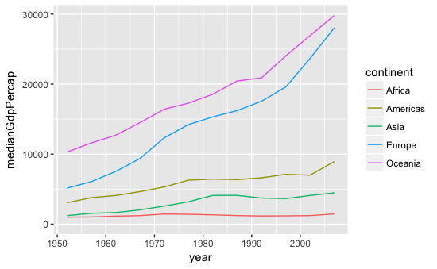

```r
# Summarize the median gdpPercap by year and continent , then save it as by_year
by_year <- gapminder %>%
  group_by(year, continent) %>%
  summarize(medianGdpPercap = median(gdpPercap))
# Create a line plot showing the change in medianGdpPercap over time, and add color per continent
ggplot(by_year, aes(year, medianGdpPercap, color = continent)) + geom_line() + expand_limits(y=0)
```

#### Create Bar Plot via geom_col()

Bar graph involves a nominal variable as the x-value, and a numerical variable as the y-value.

**Task 1:** Use group_by() and summarize() to find the median GDP per capita within each continent in the year 1952, calling the output column medianGdpPercap. Use the assignment operator <- to save it to a dataset called by_continent.

**Task 2:** Use the by_continent dataset to create a bar plot showing the median GDP per capita in each continent.

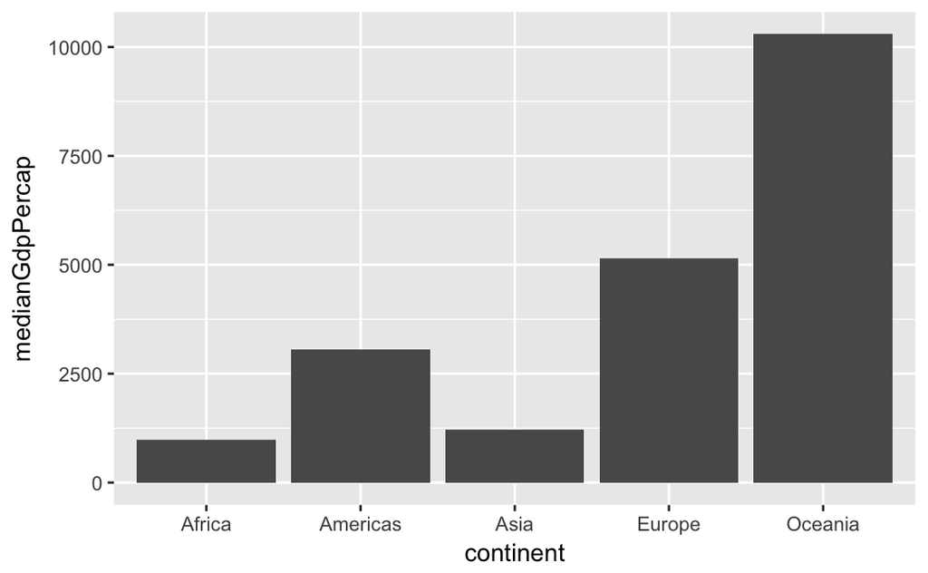

```r
by_continent <- gapminder %>%
  filter(year ==1952) %>%
  group_by(continent) %>%
  summarize(medianGdpPercap = median(gdpPercap))
ggplot(by_continent, aes(continent, medianGdpPercap)) + geom_col()
```

#### Create Histogram via geom_histogram()

Histogram involves ONLY one variable as the argument. The y-axis is simply count corresponding to the x bin. To specify a specific binwidth, we can pass it as an argument to `geom_histogram()`. Suppose we want to have bins of length 5, then `geom_histogram(binwidth = 5)` would be the right call.

Task:

Use the gapminder_1952 dataset (code is provided) to create a histogram of country population (pop) in the year 1952, putting the x-axis on a log scale with scale_x_log10():

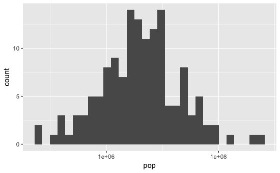

```r
gapminder_1952 <- gapminder %>%
  filter(year == 1952)
# Create a histogram of population (pop), with x on a log scale
ggplot(gapminder_1952, aes(pop)) + geom_histogram() + scale_x_log10()
```

#### Create box plots using geom_boxplot()

**Task:** Use the gapminder_1952 dataset (code is provided) to create a boxplot comparing GDP per capita (gdpPercap) among continents. Put the y-axis on a log scale with scale_y_log10().

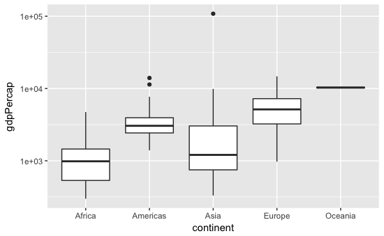

```r
gapminder_1952 <- gapminder %>%
  filter(year == 1952)
# Create a boxplot comparing gdpPercap among continents
ggplot(gapminder_1952, aes(continent, gdpPercap)) + geom_boxplot() + scale_y_log10()
```

#### Adding title via ggtitle(str)

`ggtitle()` is a good way to add title. We simple have to pass the character/string we desire inside the `ggtitle()` method.

Here’s an example:

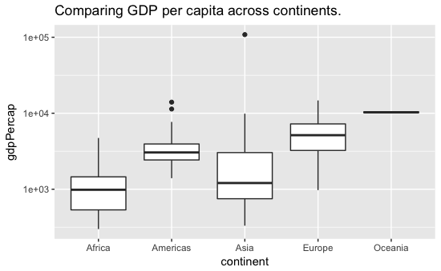

```r
gapminder_1952 <- gapminder %>%
  filter(year == 1952)
# Add a title to this graph: "Comparing GDP per capita across continents"
ggplot(gapminder_1952, aes(x = continent, y = gdpPercap)) +
  geom_boxplot() +
  scale_y_log10() + ggtitle("Comparing GDP per capita across continents.")
```